# HW2 report for MF 796

## U46881805

### Problem 1: Evaluation of a known integral using various quadratures: In this problem we are going to compute the price of a European call option with 3 month expiry, strike 12, and implied vol 20, Assume the underlying is 10 now and the interest rate is 4%.

```python
import numpy as np
import pandas as pd
import matplotlib as mql
from pandas_datareader import data as pdr
import matplotlib.pyplot as plt
from numpy.random import standard_normal as stn
from datetime import datetime
from sklearn import linear_model
import statsmodels.api as sm
import scipy.stats as scs
from scipy.stats import norm
import math
from cvxopt import matrix, solvers
import scipy.optimize as sco
from sympy import *
import warnings
warnings.filterwarnings("ignore")
```

#### 1. Use Black-Scholes formula to compute the price of the call analytically.

```python
T=1/4
K=12
vol=0.20
S0=10
r=0.04

# black-scholes
d1 = (np.log(S0 / K) + (r+vol ** 2 / 2)*T) / (vol* np.sqrt(T))
d2 = (np.log(S0 / K) + (r-vol ** 2 / 2)*T) / (vol * np.sqrt(T))
c=S0*norm.cdf(d1)-K*np.exp(-r*T)*norm.cdf(d2)

print('The price is {}'.format(c))
```

```
The price is 0.018815171090722893
```

#### with the number of nodes N = 5; 10; 50; 100 and compute the calculation error as a function of N for each of the methods

##### (a) Left Riemann rule

```
[0.0052316419693780505, 0.0014177040985003005, 5.8416092401918085e-05, 1.4876274997698696e-05]
```

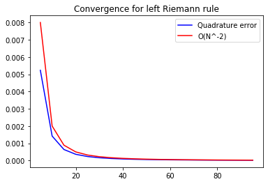

```python
# left
def BL(x):


    return (x*S0-K)/(x*sigma*np.sqrt(2*np.pi))*np.exp(-(np.log(x)-mu)**2/(2*sigma**2))

def Riemamn_left(f,N,a,b):

    x=np.linspace(a,b,N+1)
    d=(b-a)/N
    w=0
    for i in x:
        if i!=b:
            w=w+f(i)*d

    return w

mu=(r - 0.5 * vol ** 2) * T
sigma=vol*np.sqrt(T)
a=K/S0
b=1+mu+7*sigma


N=[5,10,50,100]
diff_list=[]
for i in N:
    diff=abs(np.exp(-r * T)*Riemamn_left(BL,i,a,b)-c)
    diff_list.append(diff)

print(diff_list)

# paint
NN1=np.arange(5,100,5)
diff_list_left1=[]
benchmark1=[]
for i in NN1:
    diff=abs(np.exp(-r * T)*Riemamn_left(BL,i,a,b)-c)
    diff_list_left1.append(diff)
    benchmark1.append(1/i**(2)/5)


plt.title('Convergence for left Riemann rule')
plt.plot(NN1, diff_list_left1,color='b', label='Quadrature error')
plt.plot(NN1,benchmark1,color='r',label='O(N^-2)')
plt.legend()
plt.show()
```

##### (b) Midpoint rule

```
[0.0023962337723774547, 0.0006950254147226227, 2.8663542406520692e-05, 6.925817550112318e-06]
```

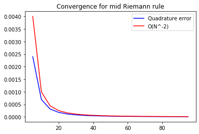

```python
# midpoint
def Riemamn_mid(f,N,a,b):

    x=np.linspace(a,b,N+1)
    d=(b-a)/N
    w=0
    for i in x:
        if i!=b:
            w=w+f(i+d/2)*d

    return w

mu=(r - 0.5 * vol ** 2) * T
sigma=vol*np.sqrt(T)
a=K/S0
b=1+mu+7*sigma


N=[5,10,50,100]
diff_list=[]
for i in N:
    diff=abs(np.exp(-r * T)*Riemamn_mid(BL,i,a,b)-c)
    diff_list.append(diff)

print(diff_list)

# paint
NN2=np.arange(5,100,5)
diff_list_left2=[]
benchmark2=[]
for i in NN2:
    diff=abs(np.exp(-r * T)*Riemamn_mid(BL,i,a,b)-c)
    diff_list_left2.append(diff)
    benchmark2.append(1 / i ** (2)/10 )

plt.figure()
plt.title('Convergence for mid Riemann rule')
plt.plot(NN2, diff_list_left2,color='b', label='Quadrature error')
plt.plot(NN1,benchmark2,color='r',label='O(N^-2)')
plt.legend()
plt.show()
```

##### (c) Gauss nodes of your choice (say explicitly why you made that choice)

```
[3.9288880335643095e-05, 3.322416599338407e-07, 3.3223483217326155e-07, 3.3223483201713644e-07]
```

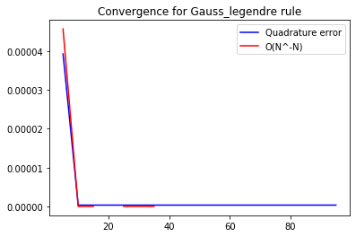

```python
# Gauss
# points, weights = np.polynomial.legendre.leggauss(N)

def Gauss_legendre(f,N,a,b):

    x,weight=np.polynomial.legendre.leggauss(N)
    x=x*(b - a) / 2 + (b + a) / 2

    w=0
    for i in range(N):
        w=w+weight[i]*f(x[i])*(b-a)/2

    return w

N=[5,10,50,100]
diff_list=[]
benchmark3=[]
for i in N:
    diff=abs(np.exp(-r * T)*Gauss_legendre(BL,i,a,b)-c)
    diff_list.append(diff)

print(diff_list)

# paint
NN3=np.arange(5,100,5)
diff_list_left3=[]
for i in NN3:
    diff=abs(np.exp(-r * T)*Gauss_legendre(BL,i,a,b)-c)
    diff_list_left3.append(diff)
    benchmark3.append(1 / i ** (i)/7)

plt.figure()
plt.title('Convergence for Gauss_legendre rule')
plt.plot(NN3, diff_list_left3,color='b', label='Quadrature error')
plt.plot(NN3,benchmark3,color='r',label='O(N^-N)')
plt.legend()
plt.show()
```

#### 3. Estimate the experimental rate of convergence of each method and compare it with the known theoretical estimate

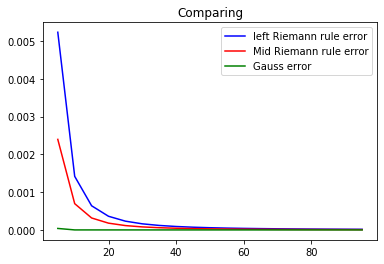

```python
# paint
plt.figure()
plt.title("Comparing")
plt.plot(NN1, diff_list_left1,color='b', label='left Riemann rule error')
plt.plot(NN2, diff_list_left2,color='red', label='Mid Riemann rule error')
plt.plot(NN3, diff_list_left3,color='green', label='Gauss error')
plt.legend()
plt.show()
```

#### 4. Which method is your favorite and why?

My favorite method is Gauss points. Because is fast and accurate。

### Problem 2: Calculation of Contingent Options: Let $S_1$ be a random variable that takes on the value of SPY one year from now and let $S_2$ take on the values of SPY 6 months from now. Assume that they are jointly normally distributed with

$$\sigma_1=20$$

$$\sigma_2=15$$

$$\rho=0.95$$

### By $\rho$ here we mean correlation between $S_1$ and $S_2$. Also, assume that interest rate is zero. Please specify where you got the current price of the underlying.

#### 1. Evaluate the price of the one year call on SPY with the strike K1 = 370. This is an example of a vanilla option.

```python
def normal_fun(x):


    return (x-K1)/(np.sqrt(2*np.pi)*sigma)*np.exp(-(x-mu1)**2/(2*sigma**2))


def Gauss_legendre(f,N,a,b):

    x,weight=np.polynomial.legendre.leggauss(N)
    x=x*(b - a) / 2 + (b + a) / 2

    w=0
    for i in range(N):
        w=w+weight[i]*f(x[i])*(b-a)/2

    return w


# 1
S0=325
sigma1=20
sigma2=15
p=0.95
r=0
T1=1
T2=0.5


K1=370
sigma=sigma1
mu1=S0
mu2=S0
a=K1
b=mu1 + 7 * sigma1

vanilla_option=Gauss_legendre(normal_fun,100,a,b)


print('The price of a vanilla option is {}'.format(vanilla_option))
```

```
The price of a vanilla option is 0.0846917671112343
```

#### 2. Evaluate the price of the one year call on SPY with the strike$K_1 = 370$, contingent on SPY at 6 months being below 365. This is a contingent option.

```python
# 2
# p=0.95

K2=365

def binormal_fun(x,y):

    return (x-K1)/(2*np.pi*sigma1*sigma2*np.sqrt(1-p**2))*np.exp(-1/(2*(1-p**2))*((x-mu1)**2/sigma1**2-(2*p*(x-mu1)*(y-mu2))/(sigma1*sigma2)+(y-mu2)**2/sigma2**2))


def Gauss_legendre_2(f,N,ax,bx,ay,by):

    x,weight_x=np.polynomial.legendre.leggauss(N)
    y, weight_y = np.polynomial.legendre.leggauss(N)
    x=x*(bx - ax) / 2 + (bx + ax) / 2
    y=y*(by - ay) / 2 + (by + ay) / 2

    w=0
    ww=0
    for i in range(N):
        w=0
        for j in range(N):
            w=w+weight_y[j]*f(x[i],y[j])*(by-ay)/2

        ww=ww+weight_x[i]*w*(bx-ax)/2

    return ww

ax=K1
bx=mu1 + 7 * sigma1
ay=mu2 - 7 * sigma2
by=K2

print('The price of a contigent option is {}'.format(Gauss_legendre_2(binormal_fun,100,ax,bx,ay,by)))
```

```
The price of a contigent option is 0.039757209693111153
```

#### 3. Calculate the contingent option again, but with $\rho = 0.8, \rho = 0.5, and \rho = 0.2$

```python
# 3
P=[0.8,0.5,0.2]
value=[]
for i in P:
    p=i

    value.append(Gauss_legendre_2(binormal_fun, 100, ax, bx, ay, by))

print(value)
```

```
[0.05975813849545861, 0.07752169352505348, 0.08326916877227501]
```

#### 4. Does dependence on $\rho$ make sense?

The dependence makes sense for the following reasons: we can get that the higher the correlation, the higher probability for the $S_2$ to bigger than 365, and thus decreases the value of the option.

#### 5. Calculate the contingent option again, but with SPY at 6 months below 360; 350, and 340

```python
# 5
p=0.95
KK=[360,350,340]
value2=[]

for i in KK:
    K2=i
    ax = K1
    bx = mu1 + 7 * sigma1
    ay = mu2 - 7 * sigma2
    by = K2

    value2.append(Gauss_legendre_2(binormal_fun, 100, ax, bx, ay, by))

print(value2)
```

```
[0.01728167007795107, 0.00046485856971137043, 3.798063176505622e-07]
```

#### 6. Does the dependence on the 6 month value make sense?

The dependence makes sense because $S_1$ and $S_2$ are highly correlative. And K is much more than the $S_0$. If K decrease, the price of the option decrease.

#### 7. Under what conditions do you think the price of the contingent option will equal the price of the vanilla one?

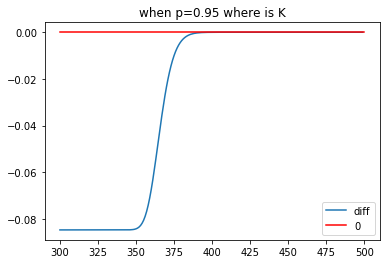

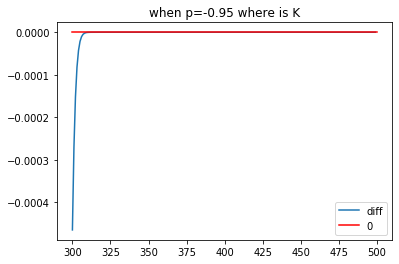

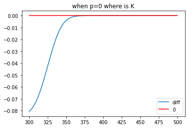

```python
# 7
# p=0.95 , k2 move
p=0.95
diff=[]
for i in np.arange(300,500,1):

    K2=i
    ax = K1
    bx = mu1 + 7 * sigma1
    ay = mu2 - 7 * sigma2
    by = K2
    diff.append(Gauss_legendre_2(binormal_fun, 100, ax, bx, ay, by)-vanilla_option)

plt.figure()
plt.title("when p=0.95 where is K")
plt.plot(np.arange(300,500,1),diff,label='diff')
plt.plot([300, 500], [0, 0], color='red', label='0')
plt.legend()
plt.show()

# p=-0.95, k2 move
p=-0.95
diff=[]
for i in np.arange(300,500,1):

    K2=i
    ax = K1
    bx = mu1 + 7 * sigma1
    ay = mu2 - 7 * sigma2
    by = K2
    diff.append(Gauss_legendre_2(binormal_fun, 100, ax, bx, ay, by)-vanilla_option)

plt.figure()
plt.title("when p=-0.95 where is K")
plt.plot(np.arange(300,500,1),diff,label='diff')
plt.plot([300, 500], [0, 0], color='red', label='0')
plt.legend()
plt.show()

# p=0, k2 move
p=0
diff=[]
for i in np.arange(300,500,1):

    K2=i
    ax = K1
    bx = mu1 + 7 * sigma1
    ay = mu2 - 7 * sigma2
    by = K2
    diff.append(Gauss_legendre_2(binormal_fun, 100, ax, bx, ay, by)-vanilla_option)

plt.figure()
plt.title("when p=0 where is K")
plt.plot(np.arange(300,500,1),diff,label='diff')
plt.plot([300, 500], [0, 0], color='red', label='0')
plt.legend()
plt.show()
```

When $\rho=0.95$ and K>380, the price will be same. When $\rho=-0.95$ and K>310, the price will be same. When $\rho=0$ and K>370, the price will be same.